# PECTitanic (FINAL FINAL)

**LUCAS DA SILVA & ALBERTO ROMERO Tipología y Ciclo de Vida de los Datos PRAC_2: 07/06/2022**

**Ejercicio 1: Descripción del dataset**

El dataset utilizado para la práctica es el archiconocido **TITANIC – Machine Learning From Disaster**, empleado en muchos ejemplos de aprendizaje automático y repositorios como Kaggle. El dataset contiene información sobre la supervivencia de los pasajeros a bordo del Titanic (si consiguieron sobrevivir o no lo consiguieron); sólo se contempla la información relativa a los pasajeros, ignorando los datos de la tripulación. El enlace de donde se ha descargado es el siguiente:

Titanic - Machine Learning from Disaster | Kaggle

https://www.kaggle.com/c/titanic

```python
import pandas as pd
import numpy as np
import matplotlib.pyplot as plt
import seaborn as sns
```

```python
train = pd.read_csv("../04_PRAC_2/TITANIC/train.csv")
test = pd.read_csv("../04_PRAC_2/TITANIC/test.csv")
final_df = train.append(test, ignore_index=True)
train.isnull().sum()
```

```
PassengerId      0
Survived         0
Pclass           0
Name             0
Sex              0
Age            177
SibSp            0
Parch            0
Ticket           0
Fare             0
Cabin          687
Embarked         2
dtype: int64
```

El objetivo del dataset es poder predecir cuáles de aquellas personas que embarcaron en el Titanic sobrevivieron al accidente y cuáles no, en base a los datos de entrenamiento (además de estudiar otras variables del dataset para poder llegar a conclusiones de interés). Es por eso que, en el conjunto de prueba (test.csv), no está incluida la variable objetivo `Survived`, para poder realizar una predicción donde solo se muestren dos atributos: el `PassengerId` y `Survived`.

**Ejercicio 2: Integración y selección de los datos**

Análisis exploratorio del dataset

1.Primeros valores del dataset (con `head()`) 2.Últimas filas del dataset (con `.tail()`)

```python
final_df.head(10)
```

|  | PassengerId | Survived | Pclass | Name | Sex | Age | SibSp | Parch | Ticket | Fare | Cabin | Embarked |
| --- | --- | --- | --- | --- | --- | --- | --- | --- | --- | --- | --- | --- |
| 0 | 1 | 0.0 | 3 | Braund, Mr. Owen Harris | male | 22.0 | 1 | 0 | A/5 21171 | 7.2500 | NaN | S |
| 1 | 2 | 1.0 | 1 | Cumings, Mrs. John Bradley (Florence Briggs Th... | female | 38.0 | 1 | 0 | PC 17599 | 71.2833 | C85 | C |
| 2 | 3 | 1.0 | 3 | Heikkinen, Miss. Laina | female | 26.0 | 0 | 0 | STON/O2. 3101282 | 7.9250 | NaN | S |
| 3 | 4 | 1.0 | 1 | Futrelle, Mrs. Jacques Heath (Lily May Peel) | female | 35.0 | 1 | 0 | 113803 | 53.1000 | C123 | S |
| 4 | 5 | 0.0 | 3 | Allen, Mr. William Henry | male | 35.0 | 0 | 0 | 373450 | 8.0500 | NaN | S |
| 5 | 6 | 0.0 | 3 | Moran, Mr. James | male | NaN | 0 | 0 | 330877 | 8.4583 | NaN | Q |
| 6 | 7 | 0.0 | 1 | McCarthy, Mr. Timothy J | male | 54.0 | 0 | 0 | 17463 | 51.8625 | E46 | S |
| 7 | 8 | 0.0 | 3 | Palsson, Master. Gosta Leonard | male | 2.0 | 3 | 1 | 349909 | 21.0750 | NaN | S |
| 8 | 9 | 1.0 | 3 | Johnson, Mrs. Oscar W (Elisabeth Vilhelmina Berg) | female | 27.0 | 0 | 2 | 347742 | 11.1333 | NaN | S |
| 9 | 10 | 1.0 | 2 | Nasser, Mrs. Nicholas (Adele Achem) | female | 14.0 | 1 | 0 | 237736 | 30.0708 | NaN | C |

```python
final_df.tail(10)
```

|  | PassengerId | Survived | Pclass | Name | Sex | Age | SibSp | Parch | Ticket | Fare | Cabin | Embarked |
| --- | --- | --- | --- | --- | --- | --- | --- | --- | --- | --- | --- | --- |
| 1299 | 1300 | NaN | 3 | Riordan, Miss. Johanna Hannah"" | female | NaN | 0 | 0 | 334915 | 7.7208 | NaN | Q |
| 1300 | 1301 | NaN | 3 | Peacock, Miss. Treasteall | female | 3.0 | 1 | 1 | SOTON/O.Q. 3101315 | 13.7750 | NaN | S |
| 1301 | 1302 | NaN | 3 | Naughton, Miss. Hannah | female | NaN | 0 | 0 | 365237 | 7.7500 | NaN | Q |
| 1302 | 1303 | NaN | 1 | Minahan, Mrs. William Edward (Lillian E Thorpe) | female | 37.0 | 1 | 0 | 19928 | 90.0000 | C78 | Q |
| 1303 | 1304 | NaN | 3 | Henriksson, Miss. Jenny Lovisa | female | 28.0 | 0 | 0 | 347086 | 7.7750 | NaN | S |
| 1304 | 1305 | NaN | 3 | Spector, Mr. Woolf | male | NaN | 0 | 0 | A.5. 3236 | 8.0500 | NaN | S |
| 1305 | 1306 | NaN | 1 | Oliva y Ocana, Dona. Fermina | female | 39.0 | 0 | 0 | PC 17758 | 108.9000 | C105 | C |
| 1306 | 1307 | NaN | 3 | Saether, Mr. Simon Sivertsen | male | 38.5 | 0 | 0 | SOTON/O.Q. 3101262 | 7.2500 | NaN | S |
| 1307 | 1308 | NaN | 3 | Ware, Mr. Frederick | male | NaN | 0 | 0 | 359309 | 8.0500 | NaN | S |
| 1308 | 1309 | NaN | 3 | Peter, Master. Michael J | male | NaN | 1 | 1 | 2668 | 22.3583 | NaN | C |

Shape

```python
final_df.shape
```

```
(1309, 12)
```

**Ejercicio 3: Limpieza de los datos**

**Ejercicio 3.1: Valores null o faltantes**

```python
final_df.info()
```

```
<class 'pandas.core.frame.DataFrame'>
RangeIndex: 1309 entries, 0 to 1308
Data columns (total 12 columns):
 #   Column       Non-Null Count  Dtype
---  ------       --------------  -----
 0   PassengerId  1309 non-null   int64
 1   Survived     891 non-null    float64
 2   Pclass       1309 non-null   int64
 3   Name         1309 non-null   object
 4   Sex          1309 non-null   object
 5   Age          1046 non-null   float64
 6   SibSp        1309 non-null   int64
 7   Parch        1309 non-null   int64
 8   Ticket       1309 non-null   object
 9   Fare         1308 non-null   float64
 10  Cabin        295 non-null    object
 11  Embarked     1307 non-null   object
dtypes: float64(3), int64(4), object(5)
memory usage: 122.8+ KB
```

```python
final_df.isnull().sum()
```

```
PassengerId       0
Survived        418
Pclass            0
Name              0
Sex               0
Age             263
SibSp             0
Parch             0
Ticket            0
Fare              1
Cabin          1014
Embarked          2
dtype: int64
```

Con shape identificamos que el dataset tiene **1309 registros** pero en `Fare` y en `Embarked` podemos esperar encontrar algunos nulls, ya que tienen un conteo menor de non-nulls https://realpython.com/pandas-python-explore-dataset/

```python
final_df.describe()
```

|  | PassengerId | Survived | Pclass | Age | SibSp | Parch | Fare |
| --- | --- | --- | --- | --- | --- | --- | --- |
| count | 1309.000000 | 891.000000 | 1309.000000 | 1046.000000 | 1309.000000 | 1309.000000 | 1308.000000 |
| mean | 655.000000 | 0.383838 | 2.294882 | 29.881138 | 0.498854 | 0.385027 | 33.295479 |
| std | 378.020061 | 0.486592 | 0.837836 | 14.413493 | 1.041658 | 0.865560 | 51.758668 |
| min | 1.000000 | 0.000000 | 1.000000 | 0.170000 | 0.000000 | 0.000000 | 0.000000 |
| 25% | 328.000000 | 0.000000 | 2.000000 | 21.000000 | 0.000000 | 0.000000 | 7.895800 |
| 50% | 655.000000 | 0.000000 | 3.000000 | 28.000000 | 0.000000 | 0.000000 | 14.454200 |
| 75% | 982.000000 | 1.000000 | 3.000000 | 39.000000 | 1.000000 | 0.000000 | 31.275000 |
| max | 1309.000000 | 1.000000 | 3.000000 | 80.000000 | 8.000000 | 9.000000 | 512.329200 |

```python
final_df.describe(include=object) ## to understand a little more the categorical variables
```

|  | Name | Sex | Ticket | Cabin | Embarked |
| --- | --- | --- | --- | --- | --- |
| count | 1309 | 1309 | 1309 | 295 | 1307 |
| unique | 1307 | 2 | 929 | 186 | 3 |
| top | Kelly, Mr. James | male | CA. 2343 | C23 C25 C27 | S |
| freq | 2 | 843 | 11 | 6 | 914 |

```python
final_df[final_df["Embarked"].isna()]
```

|  | PassengerId | Survived | Pclass | Name | Sex | Age | SibSp | Parch | Ticket | Fare | Cabin | Embarked |
| --- | --- | --- | --- | --- | --- | --- | --- | --- | --- | --- | --- | --- |
| 61 | 62 | 1.0 | 1 | Icard, Miss. Amelie | female | 38.0 | 0 | 0 | 113572 | 80.0 | B28 | NaN |
| 829 | 830 | 1.0 | 1 | Stone, Mrs. George Nelson (Martha Evelyn) | female | 62.0 | 0 | 0 | 113572 | 80.0 | B28 | NaN |

With a little research it was possible to identify that both passengers boarded the Titanic in Southampton, this way we updated the values, source: https://www.encyclopedia-titanica.org/

```python
final_df["Embarked"].fillna("S", inplace = True)
```

```python
final_df[final_df["Fare"].isna()]
```

|  | PassengerId | Survived | Pclass | Name | Sex | Age | SibSp | Parch | Ticket | Fare | Cabin | Embarked |
| --- | --- | --- | --- | --- | --- | --- | --- | --- | --- | --- | --- | --- |
| 1043 | 1044 | NaN | 3 | Storey, Mr. Thomas | male | 60.5 | 0 | 0 | 3701 | NaN | NaN | S |

In the same website we identified that the missing value in Fare was actually an employee and set the value to "0"

```python
final_df["Fare"].fillna(0, inplace = True)
```

For "Age" we decided to fill the values with the mean.

```python
final_df["Age"] = final_df["Age"].fillna(final_df["Age"].mean())
```

More than 70% of the values in column Cavin are missing so we decided to drop this column

```python
final_df.drop('Cabin', axis=1, inplace=True)
```

Comprobamos que, a excepción del atributo `Survived`, ya no quedan valores nulos en el dataframe (los 418 valores faltantes se tratarán en el punto 4.3)

```python
final_df.isnull().sum()
```

```
PassengerId      0
Survived       418
Pclass           0
Name             0
Sex              0
Age              0
SibSp            0
Parch            0
Ticket           0
Fare             0
Embarked         0
dtype: int64
```

**Ejercicio 3.2: Valores extremos (outliers)**

Podemos echar un vistazo preliminar a la distribución de todas las variables:

```
array([[<AxesSubplot:title={'center':'Survived'}>,
        <AxesSubplot:title={'center':'Pclass'}>,
        <AxesSubplot:title={'center':'Age'}>],
       [<AxesSubplot:title={'center':'SibSp'}>,
        <AxesSubplot:title={'center':'Parch'}>,
        <AxesSubplot:title={'center':'Fare'}>],
       [<AxesSubplot:>, <AxesSubplot:>, <AxesSubplot:>]], dtype=object)
```

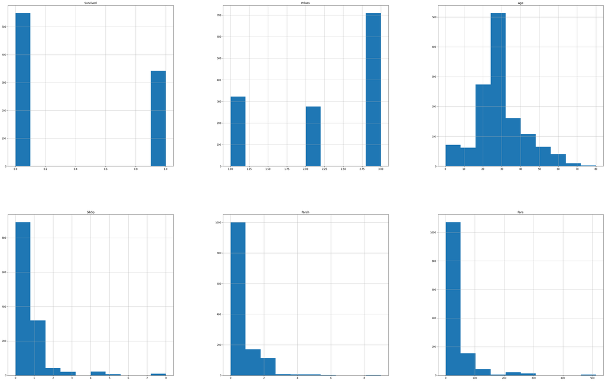

```python
final_df[['Survived','Pclass','Age','SibSp','Parch', 'Fare']].hist(layout=(3,3), figsize=(45,45))
```

```python
final_df.loc[final_df['Fare'].idxmax()]
```

```
PassengerId                 259
Survived                      1
Pclass                        1
Name           Ward, Miss. Anna
Sex                      female
Age                          35
SibSp                         0
Parch                         0
Ticket                 PC 17755
Fare                    512.329
Embarked                      C
Name: 258, dtype: object
```

Observing the plots and the values in the dataframe ( using "describe") we identified that "Fare" has outliers. We decided to check the values that are 3 standar deviations from the mean in both directions. There are 38 values like this and we decided to fill them with the median as the mean can be more sensitive to outliers.

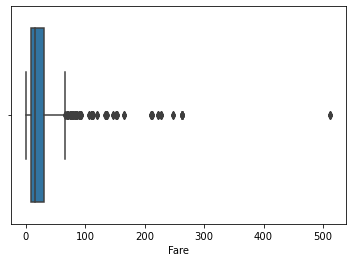

```python
import seaborn as sns
sns.boxplot(x=final_df["Fare"])
```

```python
fare_mean = final_df['Fare'].mean() # Check outliers
fare_std = final_df['Fare'].std()
low= fare_mean -(3 * fare_std)
high= fare_mean + (3 * fare_std)
fare_outliers = final_df[(final_df['Fare'] < low) | (final_df['Fare'] > high)]
fare_outliers
```

|  | PassengerId | Survived | Pclass | Name | Sex | Age | SibSp | Parch | Ticket | Fare | Embarked |
| --- | --- | --- | --- | --- | --- | --- | --- | --- | --- | --- | --- |
| 27 | 28 | 0.0 | 1 | Fortune, Mr. Charles Alexander | male | 19.000000 | 3 | 2 | 19950 | 263.0000 | S |
| 88 | 89 | 1.0 | 1 | Fortune, Miss. Mabel Helen | female | 23.000000 | 3 | 2 | 19950 | 263.0000 | S |
| 118 | 119 | 0.0 | 1 | Baxter, Mr. Quigg Edmond | male | 24.000000 | 0 | 1 | PC 17558 | 247.5208 | C |
| 258 | 259 | 1.0 | 1 | Ward, Miss. Anna | female | 35.000000 | 0 | 0 | PC 17755 | 512.3292 | C |
| 299 | 300 | 1.0 | 1 | Baxter, Mrs. James (Helene DeLaudeniere Chaput) | female | 50.000000 | 0 | 1 | PC 17558 | 247.5208 | C |
| 311 | 312 | 1.0 | 1 | Ryerson, Miss. Emily Borie | female | 18.000000 | 2 | 2 | PC 17608 | 262.3750 | C |
| 341 | 342 | 1.0 | 1 | Fortune, Miss. Alice Elizabeth | female | 24.000000 | 3 | 2 | 19950 | 263.0000 | S |
| 377 | 378 | 0.0 | 1 | Widener, Mr. Harry Elkins | male | 27.000000 | 0 | 2 | 113503 | 211.5000 | C |
| 380 | 381 | 1.0 | 1 | Bidois, Miss. Rosalie | female | 42.000000 | 0 | 0 | PC 17757 | 227.5250 | C |
| 438 | 439 | 0.0 | 1 | Fortune, Mr. Mark | male | 64.000000 | 1 | 4 | 19950 | 263.0000 | S |
| 527 | 528 | 0.0 | 1 | Farthing, Mr. John | male | 29.881138 | 0 | 0 | PC 17483 | 221.7792 | S |
| 557 | 558 | 0.0 | 1 | Robbins, Mr. Victor | male | 29.881138 | 0 | 0 | PC 17757 | 227.5250 | C |
| 679 | 680 | 1.0 | 1 | Cardeza, Mr. Thomas Drake Martinez | male | 36.000000 | 0 | 1 | PC 17755 | 512.3292 | C |
| 689 | 690 | 1.0 | 1 | Madill, Miss. Georgette Alexandra | female | 15.000000 | 0 | 1 | 24160 | 211.3375 | S |
| 700 | 701 | 1.0 | 1 | Astor, Mrs. John Jacob (Madeleine Talmadge Force) | female | 18.000000 | 1 | 0 | PC 17757 | 227.5250 | C |
| 716 | 717 | 1.0 | 1 | Endres, Miss. Caroline Louise | female | 38.000000 | 0 | 0 | PC 17757 | 227.5250 | C |
| 730 | 731 | 1.0 | 1 | Allen, Miss. Elisabeth Walton | female | 29.000000 | 0 | 0 | 24160 | 211.3375 | S |
| 737 | 738 | 1.0 | 1 | Lesurer, Mr. Gustave J | male | 35.000000 | 0 | 0 | PC 17755 | 512.3292 | C |
| 742 | 743 | 1.0 | 1 | Ryerson, Miss. Susan Parker "Suzette" | female | 21.000000 | 2 | 2 | PC 17608 | 262.3750 | C |
| 779 | 780 | 1.0 | 1 | Robert, Mrs. Edward Scott (Elisabeth Walton Mc... | female | 43.000000 | 0 | 1 | 24160 | 211.3375 | S |
| 915 | 916 | NaN | 1 | Ryerson, Mrs. Arthur Larned (Emily Maria Borie) | female | 48.000000 | 1 | 3 | PC 17608 | 262.3750 | C |
| 944 | 945 | NaN | 1 | Fortune, Miss. Ethel Flora | female | 28.000000 | 3 | 2 | 19950 | 263.0000 | S |
| 950 | 951 | NaN | 1 | Chaudanson, Miss. Victorine | female | 36.000000 | 0 | 0 | PC 17608 | 262.3750 | C |
| 955 | 956 | NaN | 1 | Ryerson, Master. John Borie | male | 13.000000 | 2 | 2 | PC 17608 | 262.3750 | C |
| 960 | 961 | NaN | 1 | Fortune, Mrs. Mark (Mary McDougald) | female | 60.000000 | 1 | 4 | 19950 | 263.0000 | S |
| 965 | 966 | NaN | 1 | Geiger, Miss. Amalie | female | 35.000000 | 0 | 0 | 113503 | 211.5000 | C |
| 966 | 967 | NaN | 1 | Keeping, Mr. Edwin | male | 32.500000 | 0 | 0 | 113503 | 211.5000 | C |
| 972 | 973 | NaN | 1 | Straus, Mr. Isidor | male | 67.000000 | 1 | 0 | PC 17483 | 221.7792 | S |
| 1005 | 1006 | NaN | 1 | Straus, Mrs. Isidor (Rosalie Ida Blun) | female | 63.000000 | 1 | 0 | PC 17483 | 221.7792 | S |
| 1033 | 1034 | NaN | 1 | Ryerson, Mr. Arthur Larned | male | 61.000000 | 1 | 3 | PC 17608 | 262.3750 | C |
| 1047 | 1048 | NaN | 1 | Bird, Miss. Ellen | female | 29.000000 | 0 | 0 | PC 17483 | 221.7792 | S |
| 1075 | 1076 | NaN | 1 | Douglas, Mrs. Frederick Charles (Mary Helene B... | female | 27.000000 | 1 | 1 | PC 17558 | 247.5208 | C |
| 1093 | 1094 | NaN | 1 | Astor, Col. John Jacob | male | 47.000000 | 1 | 0 | PC 17757 | 227.5250 | C |
| 1109 | 1110 | NaN | 1 | Widener, Mrs. George Dunton (Eleanor Elkins) | female | 50.000000 | 1 | 1 | 113503 | 211.5000 | C |
| 1215 | 1216 | NaN | 1 | Kreuchen, Miss. Emilie | female | 39.000000 | 0 | 0 | 24160 | 211.3375 | S |
| 1234 | 1235 | NaN | 1 | Cardeza, Mrs. James Warburton Martinez (Charlo... | female | 58.000000 | 0 | 1 | PC 17755 | 512.3292 | C |
| 1266 | 1267 | NaN | 1 | Bowen, Miss. Grace Scott | female | 45.000000 | 0 | 0 | PC 17608 | 262.3750 | C |
| 1298 | 1299 | NaN | 1 | Widener, Mr. George Dunton | male | 50.000000 | 1 | 1 | 113503 | 211.5000 | C |

```python
print('skewness value of Fare: ',final_df['Fare'].skew()) #
```

```
skewness value of Fare:  4.368574813093145
```

```python
#Fill outliers with median value based on Std
import numpy as np
final_df['Fare'] = np.where((final_df['Fare'] < low) | (final_df['Fare'] > high),final_df['Fare'].median(),final_df['Fare'])
```

```python
print('skewness value of Fare: ',final_df['Fare'].skew()) # Check skew reduction
```

```
skewness value of Fare:  2.3641051161948408
```

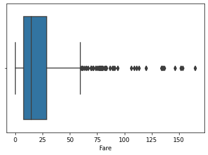

```python
import seaborn as sns
sns.boxplot(x=final_df["Fare"])
```

```python
# Observamos aquellas filas con Edad menor a 1
final_df.loc[(final_df['Age']<1)].sort_values(by=["Age"])
```

|  | PassengerId | Survived | Pclass | Name | Sex | Age | SibSp | Parch | Ticket | Fare | Embarked |
| --- | --- | --- | --- | --- | --- | --- | --- | --- | --- | --- | --- |
| 1245 | 1246 | NaN | 3 | Dean, Miss. Elizabeth Gladys Millvina"" | female | 0.17 | 1 | 2 | C.A. 2315 | 20.5750 | S |
| 1092 | 1093 | NaN | 3 | Danbom, Master. Gilbert Sigvard Emanuel | male | 0.33 | 0 | 2 | 347080 | 14.4000 | S |
| 803 | 804 | 1.0 | 3 | Thomas, Master. Assad Alexander | male | 0.42 | 0 | 1 | 2625 | 8.5167 | C |
| 755 | 756 | 1.0 | 2 | Hamalainen, Master. Viljo | male | 0.67 | 1 | 1 | 250649 | 14.5000 | S |
| 469 | 470 | 1.0 | 3 | Baclini, Miss. Helene Barbara | female | 0.75 | 2 | 1 | 2666 | 19.2583 | C |
| 644 | 645 | 1.0 | 3 | Baclini, Miss. Eugenie | female | 0.75 | 2 | 1 | 2666 | 19.2583 | C |
| 1172 | 1173 | NaN | 3 | Peacock, Master. Alfred Edward | male | 0.75 | 1 | 1 | SOTON/O.Q. 3101315 | 13.7750 | S |
| 78 | 79 | 1.0 | 2 | Caldwell, Master. Alden Gates | male | 0.83 | 0 | 2 | 248738 | 29.0000 | S |
| 831 | 832 | 1.0 | 2 | Richards, Master. George Sibley | male | 0.83 | 1 | 1 | 29106 | 18.7500 | S |
| 1198 | 1199 | NaN | 3 | Aks, Master. Philip Frank | male | 0.83 | 0 | 1 | 392091 | 9.3500 | S |
| 305 | 306 | 1.0 | 1 | Allison, Master. Hudson Trevor | male | 0.92 | 1 | 2 | 113781 | 151.5500 | S |
| 1141 | 1142 | NaN | 2 | West, Miss. Barbara J | female | 0.92 | 1 | 2 | C.A. 34651 | 27.7500 | S |

```python
# Todos los valores menores a 1 se sustituirán por 0
final_df.loc[final_df["Age"] < 1, "Age"] = 0
```

```python
# Cambiamos la variable Age de float a int
final_df = final_df.astype({"Age": int})
```

**Ejercicio 4: Análisis de los datos**

**Ejercicio 4.1: Subconjunto o grupos de datos a analizar**

```python
under18_df= final_df.query("Age < 18") # People not older than 18
over18_df=final_df.query("Age >= 18") # People older than 18
firstClass_df= final_df.query("Pclass == 1") # Passengers in first class
secondClass_df= final_df.query("Pclass == 2") # Passengers in second class
thirdClass_df= final_df.query("Pclass == 3") # Passengers in third class
alive_df = final_df.query("Survived == 1") # Passengers that survived
dead_df = final_df.query("Survived == 0") # Passengers that died
test = final_df[final_df.Survived.isnull()] # Split again train and test value.isnull()'
train = final_df[final_df.Survived.notnull()]
```

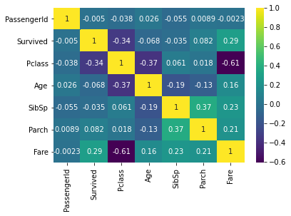

```python
# Primero se calcula la matriz de correlaciones del dataframe
import seaborn as sns
import matplotlib.pyplot as plt
matriz_corr = final_df.corr()

# Luego utilizamos el mapa de calor para la matriz de correlaciones (enseñamos las cantidades con annot=True)
sns.heatmap(matriz_corr, annot=True, cmap="viridis")

plt.show()
```

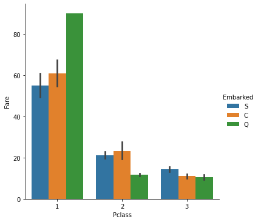

```python
sns.catplot(x="Pclass", y="Fare", hue="Embarked", kind="bar", data=final_df)
```

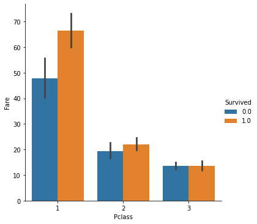

```python
sns.catplot(x="Pclass", y="Fare", hue="Survived", kind="bar", data=final_df)
```

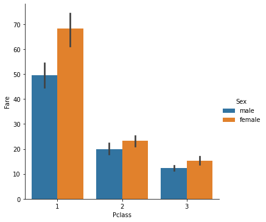

```python
sns.catplot(x="Pclass", y="Fare", hue="Sex", kind="bar", data=final_df)
```

**Ejercicio 4.2: Comprobación normalidad y homogeneidad de la varianza**

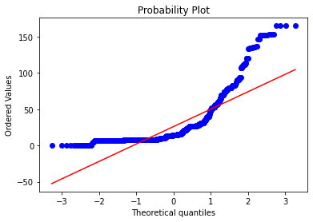

```python
import pylab
import scipy.stats as stats

# Gráfica Q-Q plot de Fare
stats.probplot(final_df['Fare'], dist="norm", plot=pylab)
pylab.show()
```

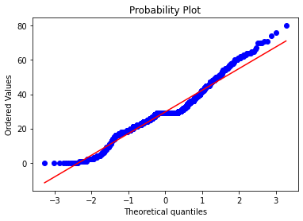

```python
# Gráfica Q-Q plot de Age

stats.probplot(final_df['Age'], dist="norm", plot=pylab)
pylab.show()
```

Perform Fligner’s test for equal variances.

Fligner’s test tests the null hypothesis that all input samples are from populations with equal variances. Here we tested homogeniety in the groups of survivors or victims regarding age.Considering the level of significance of alpha value to be 0.05, we can see that p-value is lower than 0.05 comparing age in the population that survived or not. We ignore the null hypothesis. The groups problably do not have equal variance.

```python
# importing packages and modules
import scipy.stats as stats
from scipy.stats import fligner

stat,p= fligner(dead_df["Age"],alive_df["Age"]) # Passengers that survived

print(stat,p)
```

```
5.469269893878385 0.01935370908429266
```

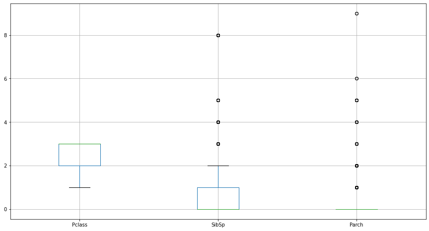

```python
plt.figure(figsize = (15,8))

final_df[["Pclass", "SibSp", "Parch"]].boxplot()
```

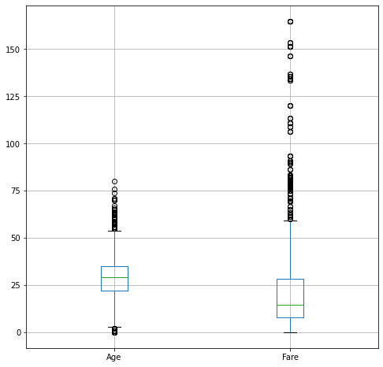

```python
plt.figure(figsize = (8,8))
final_df[["Age", "Fare"]].boxplot()
```

**Ejercicio 4.3: Aplicación de pruebas estadísticas: contraste de hipótesis, correlaciones, regresiones...**

For this exercise we decided to predict `Survived`, for that purpose we divide the dataset in train and test again and create a correlation matrix in the training dataset.

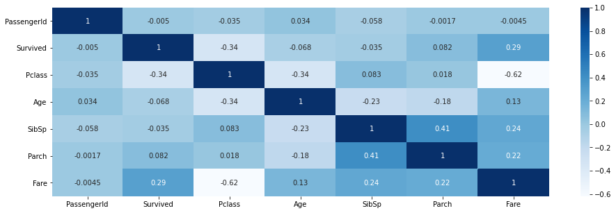

```python
# calculate the correlation matrix
corr =  train.corr()

# plot the heatmap
plt.figure(figsize = (16,5))
sns.heatmap(corr, cmap="Blues", annot=True)
```

```python
from sklearn.model_selection import train_test_split
from sklearn.linear_model import LogisticRegression
from sklearn.metrics import accuracy_score, confusion_matrix

traindata = train[["Age","Pclass","Fare","PassengerId", "Survived","SibSp", "Parch"]]
X = traindata.drop('Survived',axis=1)
y = traindata['Survived']
X_train, X_test, y_train, y_test = train_test_split(X,y, test_size=0.2, random_state=25)
```

```python
log_reg = LogisticRegression()
log_reg.fit(X_train, y_train)
y_pred = log_reg.predict(X_test)
y_pred
```

```
array([0., 0., 0., 1., 0., 0., 0., 0., 1., 0., 0., 0., 0., 0., 0., 0., 1.,
       0., 1., 1., 0., 0., 0., 0., 0., 0., 0., 0., 0., 0., 0., 1., 1., 0.,
       0., 0., 0., 0., 1., 0., 0., 0., 0., 0., 0., 0., 0., 1., 0., 1., 1.,
       1., 0., 0., 1., 1., 1., 1., 1., 0., 1., 0., 1., 1., 0., 1., 0., 0.,
       0., 0., 0., 0., 0., 1., 0., 0., 0., 0., 0., 0., 0., 1., 0., 0., 0.,
       0., 0., 1., 0., 0., 0., 0., 0., 1., 0., 0., 0., 0., 0., 1., 0., 0.,
       1., 0., 1., 0., 1., 0., 0., 0., 0., 0., 1., 1., 0., 0., 1., 0., 0.,
       1., 0., 1., 0., 0., 1., 0., 0., 0., 0., 1., 1., 0., 1., 0., 1., 0.,
       0., 0., 1., 1., 1., 0., 0., 1., 0., 1., 1., 0., 0., 0., 1., 0., 0.,
       0., 0., 1., 0., 0., 0., 0., 0., 0., 0., 0., 0., 0., 0., 0., 0., 0.,
       1., 0., 0., 0., 0., 1., 1., 1., 1.])
```

```python
accuracy_score(y_pred, y_test)
```

```
0.7150837988826816
```

```python
confusion_matrix(y_pred, y_test)
```

```
array([[94, 33],
       [18, 34]], dtype=int64)
```

```python
final_test = test[["Age","Pclass","Fare","PassengerId","SibSp", "Parch"]]
final_test['Survived'] = log_reg.predict(final_test)
final_test['PassengerId'] = test['PassengerId']

submission = final_test[['PassengerId','Survived']]

submission.to_csv("../04_PRAC_2/TITANIC/submission.csv", index=False)
# submission.to_csv("C:/Users/llcas/Área de Trabalho/titanic pec/submission.csv", index=False)

submission.tail()
```

|  | PassengerId | Survived |
| --- | --- | --- |
| 1304 | 1305 | 0.0 |
| 1305 | 1306 | 1.0 |
| 1306 | 1307 | 0.0 |
| 1307 | 1308 | 0.0 |
| 1308 | 1309 | 0.0 |

```python
# Fusionamos la nueva variable submission con los valores de prueba
test = test.merge(submission, on="PassengerId", how="left")
```

```python
final_df = train.append(test, ignore_index=True)
```

```python
final_df
```

|  | PassengerId | Survived | Pclass | Name | Sex | Age | SibSp | Parch | Ticket | Fare | Embarked | Survived_x | Survived_y |
| --- | --- | --- | --- | --- | --- | --- | --- | --- | --- | --- | --- | --- | --- |
| 0 | 1 | 0.0 | 3 | Braund, Mr. Owen Harris | male | 22 | 1 | 0 | A/5 21171 | 7.2500 | S | NaN | NaN |
| 1 | 2 | 1.0 | 1 | Cumings, Mrs. John Bradley (Florence Briggs Th... | female | 38 | 1 | 0 | PC 17599 | 71.2833 | C | NaN | NaN |
| 2 | 3 | 1.0 | 3 | Heikkinen, Miss. Laina | female | 26 | 0 | 0 | STON/O2. 3101282 | 7.9250 | S | NaN | NaN |
| 3 | 4 | 1.0 | 1 | Futrelle, Mrs. Jacques Heath (Lily May Peel) | female | 35 | 1 | 0 | 113803 | 53.1000 | S | NaN | NaN |
| 4 | 5 | 0.0 | 3 | Allen, Mr. William Henry | male | 35 | 0 | 0 | 373450 | 8.0500 | S | NaN | NaN |
| ... | ... | ... | ... | ... | ... | ... | ... | ... | ... | ... | ... | ... | ... |
| 1304 | 1305 | 0.0 | 3 | Spector, Mr. Woolf | male | 29 | 0 | 0 | A.5. 3236 | 8.0500 | S | NaN | 0.0 |
| 1305 | 1306 | 1.0 | 1 | Oliva y Ocana, Dona. Fermina | female | 39 | 0 | 0 | PC 17758 | 108.9000 | C | NaN | 1.0 |
| 1306 | 1307 | 0.0 | 3 | Saether, Mr. Simon Sivertsen | male | 38 | 0 | 0 | SOTON/O.Q. 3101262 | 7.2500 | S | NaN | 0.0 |
| 1307 | 1308 | 0.0 | 3 | Ware, Mr. Frederick | male | 29 | 0 | 0 | 359309 | 8.0500 | S | NaN | 0.0 |
| 1308 | 1309 | 0.0 | 3 | Peter, Master. Michael J | male | 29 | 1 | 1 | 2668 | 22.3583 | C | NaN | 0.0 |

1309 rows × 13 columns

```python
final_df.isnull().sum()
```

```
PassengerId       0
Survived          0
Pclass            0
Name              0
Sex               0
Age               0
SibSp             0
Parch             0
Ticket            0
Fare              0
Embarked          0
Survived_x     1309
Survived_y      891
dtype: int64
```

### CONTRASTE DE HIPÓTESIS

Queremos centrar el análisis en indagar un poco más sobre las características de los pasajeros que viajaban a bordo del Titanic. Para ello, queremos conocer la respuesta a la pregunta:

**¿Los pasajeros de la Clase 1 son más jóvenes que los de la Clase 3?**

Para contestar a esta pregunta, se llevará a cabo un contraste de hipótesis:

- $H_0 = μ_1 - μ_2 = 0$
- $H_1 = μ_1 - μ_2 > 0$

Se utilizará un test de hipótesis **de dos muestras sobre la media**. Primero extraemos los valores de la variable categórica `Pclass` que utilizaremos en el test:

```python
# A modo informativo, veamos cuántos pasajeros hay en cada clase
final_df.groupby("Pclass").size()
```

```
Pclass
1    323
2    277
3    709
dtype: int64
```

```python
# Extraemos todas las observaciones de "Age" de los pasajeros en Clase 1
class_1 = firstClass_df["Age"]

# Extraemos todas las observaciones de los pasajeros en Clase 3
class_3 = thirdClass_df["Age"]
```

Ahora, obtenemos los valores de la media (μ) y la desviación típica (σ) de cada muestra:

```python
# Importamos el módulo "stats" de la librería scipy

from scipy import stats
```

```python
# Calculamos la media y la desv. típica de la edad de la Clase 1
mu_1, sigma_1 = stats.norm.fit(class_1)
```

```python
print(mu_1)
print(sigma_1)
```

```
37.925696594427244
14.022562173217601
```

```python
# Calculamos la media y la desv. típica de la edad de la Clase 3
mu_3, sigma_3 = stats.norm.fit(class_3)
```

```python
print(mu_3)
print(sigma_3)
```

```
26.0197461212976
10.224402041912825
```

Vamos a comprobar, mediante el **test Shapiro-Wilk**, si los datos de la muestra siguen o no una distribución normal. Asumiremos un nivel de significancia $\alpha=0.05$

```python
from scipy.stats import shapiro
```

```python
stat, p = shapiro(class_1)

print('stat=%.3f, p=%.3f' % (stat, p))
if p > 0.05:
    print('Sigue una distribución normal')
else:
    print('No sigue una distribución normal')
```

```
stat=0.981, p=0.000
No sigue una distribución normal
```

```python
stat, p = shapiro(class_3)

print('stat=%.3f, p=%.3f' % (stat, p))
if p > 0.05:
    print('Sigue una distribución normal')
else:
    print('No sigue una distribución normal')
```

```
stat=0.929, p=0.000
No sigue una distribución normal
```

FUENTE: https://www.cienciadedatos.net/documentos/pystats10-t-test-python.html

```python
# Importamos la función "ttest_rel" de scipy
from scipy.stats import ttest_rel
```

Como las muestras deben tener el mismo número de observaciones, vamos a quedarnos con los 250 primeros valores de `Class_1` y `Class_3`:

```python
# 250 primeras observaciones de la Clase 1
c1 = class_1[:250]
c1
```

```
1       38
3       35
6       54
11      58
23      28
        ..
987     76
991     43
1003    36
1005    63
1009    36
Name: Age, Length: 250, dtype: int32
```

```python
# 250 primeras observaciones de la Clase 3
c3 = class_3[:250]
c3
```

```
0      22
2      26
4      35
5      29
7       2
       ..
431    29
433    17
436    21
441    20
442    25
Name: Age, Length: 250, dtype: int32
```

Veamos la distribución de las 2 muestras:

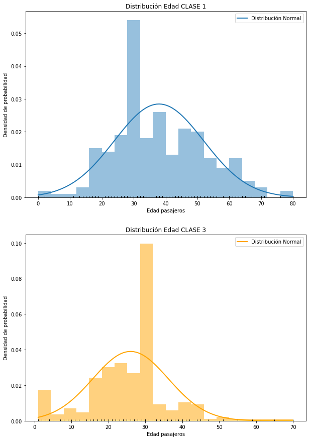

```python
fig, axs = plt.subplots(2, figsize=(10, 15))

# Valores teóricos de la normal para CLASE 1
x_1 = np.linspace(min(c1), max(c1), num=100)
y_1 = stats.norm.pdf(x_1, mu_1, sigma_1)

# Gráfico distribución de la CLASE 1
axs[0].plot(x_1, y_1, linewidth=2, label='Distribución Normal')
axs[0].hist(x=c1, density=True, bins=20, color="#3182bd", alpha=0.5)
axs[0].plot(c1, np.full_like(c1, -0.01), '|k', markeredgewidth=1)
axs[0].set_title('Distribución Edad CLASE 1')
axs[0].set_xlabel('Edad pasajeros')
axs[0].set_ylabel('Densidad de probabilidad')
axs[0].legend()


# Valores teóricos de la normal para CLASE 3
x_3 = np.linspace(min(c3), max(c3), num=100)
y_3 = stats.norm.pdf(x_3, mu_3, sigma_3)

# Gráfico distribución de la CLASE 1
axs[1].plot(x_3, y_3, linewidth=2, color="orange", label='Distribución Normal')
axs[1].hist(x=c3, density=True, bins=20, color="orange", alpha=0.5)
axs[1].plot(c3, np.full_like(c3, -0.01), '|k', markeredgewidth=1)
axs[1].set_title('Distribución Edad CLASE 3')
axs[1].set_xlabel('Edad pasajeros')
axs[1].set_ylabel('Densidad de probabilidad')
axs[1].legend()


# FUENTE: https://www.cienciadedatos.net/documentos/pystats10-t-test-python.html
```

```python
# Aplicamos ttest_rel en las dos muestras
ttest , p_valor = stats.ttest_rel(c1, c3)

# Mostramos el valor de p_valor
print(p_valor)

# Test de hipótesis
if p_valor<0.05:
    print("Rechazar hipótesis nula (aceptar hipótesis alternativa)")
else:
    print("Aceptar hipótesis nula")
```

```
2.6226183808947603e-19
Rechazar hipótesis nula (aceptar hipótesis alternativa)
```

Test Kruskal-Wallis por no ser necesaria normalidad

```python
# Aplicamos kruskal en las dos muestras
krusk , p_valor = stats.kruskal(c1, c3)

# Mostramos el valor de p_valor
print(p_valor)

# Test de hipótesis
if p_valor<0.05:
    print("Rechazar hipótesis nula (aceptar hipótesis alternativa)")
else:
    print("Aceptar hipótesis nula")
```

```
2.1246102724689367e-20
Rechazar hipótesis nula (aceptar hipótesis alternativa)
```

```python
ttest
```

```
9.77422413454502
```

```python
krusk
```

```
85.67142487219343
```

Así pues, debemos aceptar la hipótesis alternativa: podemos afirmar que **existe diferencia significativa entre la media de edad** de los pasajeros de la clase 1 y los pasajeros de la clase 3.

FUENTE: https://towardsdatascience.com/hypothesis-testing-in-machine-learning-using-python-a0dc89e169ce

**Ejercicio 5: Tablas y gráficas adicionales**

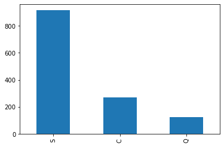

```python
final_df['Embarked'].value_counts().plot(kind='bar')
```

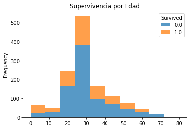

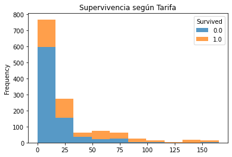

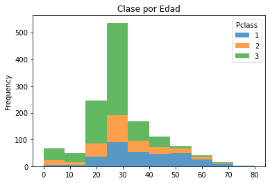

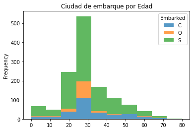

```python
import matplotlib.pyplot as plt
survived_age = final_df.pivot(columns='Survived', values='Age')
survived_fare = final_df.pivot(columns='Survived', values='Fare')
class_age = final_df.pivot(columns='Pclass', values='Age')
embarked_fare = final_df.pivot(columns='Embarked', values='Age')


survived_age.plot.hist(stacked=True, alpha=0.75, title="Supervivencia por Edad")
survived_fare.plot.hist(stacked=True, alpha=0.75, title="Supervivencia según Tarifa")
class_age.plot.hist(stacked=True, alpha=0.75, title="Clase por Edad")
embarked_fare.plot.hist(stacked=True, alpha=0.75, title="Ciudad de embarque por Edad")

plt.show()
```

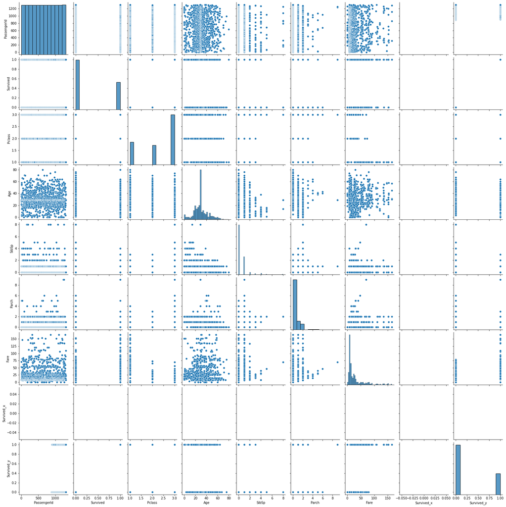

```python
sns.pairplot(final_df)
```